# Global Child Mortality: A Data-Driven Analysis

Author

Naveen Bhandari

Published

April 13, 2025

## Introduction

This report examines global trends in child mortality, one of the key indicators of a nation’s health system effectiveness and overall development status. Despite significant improvements in recent decades, millions of children still die each year from preventable causes, with stark disparities between rich and poor countries.

This analysis uses data from UNICEF to:

- Identify countries with the highest under-five mortality rates
- Analyze trends in child mortality over time
- Explore the relationship between economic indicators and child mortality
- Examine regional disparities to highlight areas needing urgent intervention

## Data Preparation

The analysis uses multiple datasets provided by UNICEF to create a comprehensive picture of child mortality worldwide.

## Global Child Mortality: Current Situation

### Geographic Distribution of Child Mortality

The map below shows the global distribution of under-five mortality rates, highlighting regions with the highest burden of child deaths.

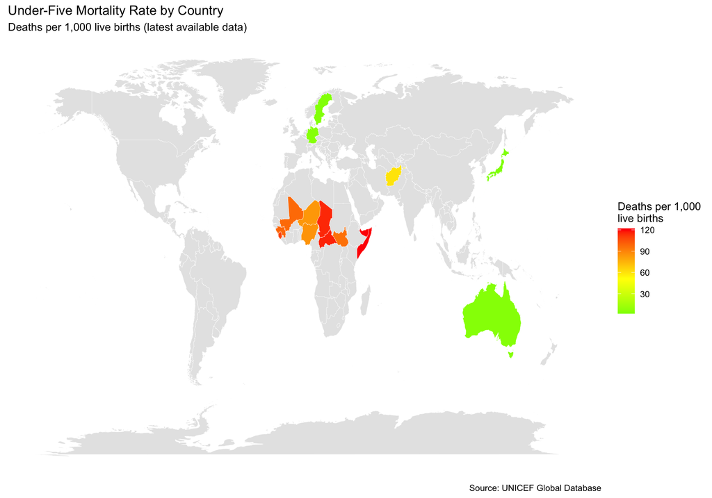

### Countries with Highest Child Mortality

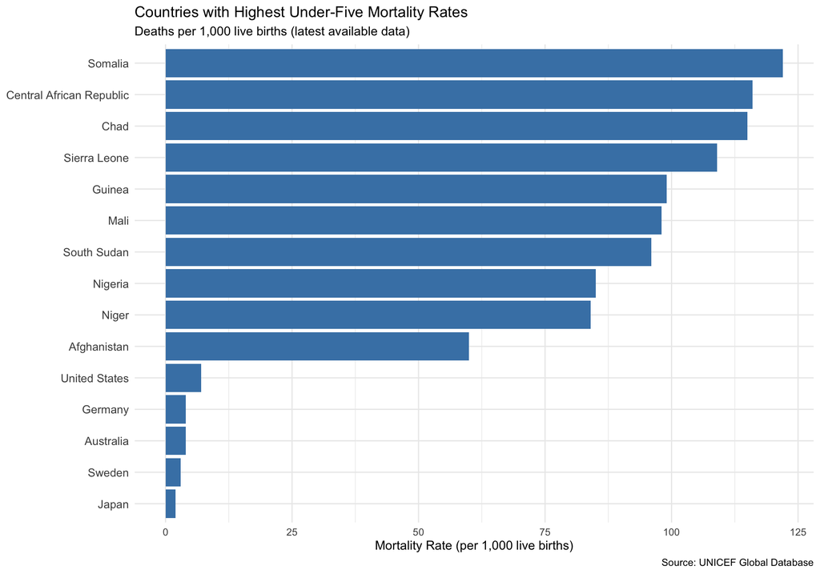

This chart highlights countries facing the most severe challenges in child survival. These nations require targeted interventions and support from international organizations like UNICEF to reduce preventable child deaths.

## Economic Factors and Child Mortality

### Relationship Between GDP and Child Mortality

Economic development is often associated with improvements in child survival. The scatter plot below explores this relationship.

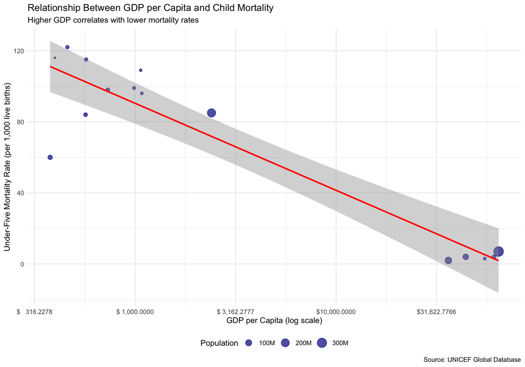

The analysis shows a strong negative correlation between GDP per capita and child mortality rates. Countries with higher economic development generally have lower child mortality, suggesting that economic growth can contribute to improving child survival.

## Trends Over Time

### Progress in Reducing Child Mortality

Tracking changes over time helps assess progress toward global health targets.

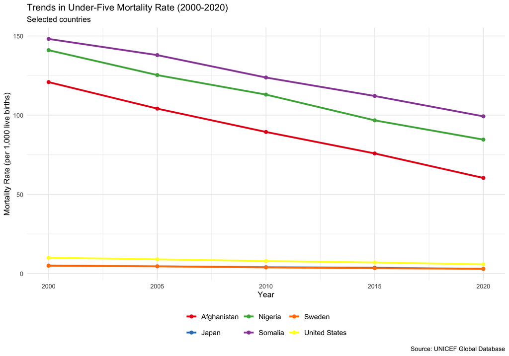

The time series reveals encouraging trends in child mortality reduction across diverse countries. However, progress remains uneven, with some countries achieving faster improvements than others.

## Discussion

### Key Findings

1. **Geographic disparities**: Child mortality remains highest in Sub-Saharan Africa and parts of South Asia, while developed regions have achieved much lower rates.
2. **Economic impact**: There is a strong inverse relationship between economic development (measured by GDP per capita) and child mortality, suggesting that poverty reduction strategies can help improve child survival.
3. **Progress over time**: Most countries have made significant progress in reducing child mortality over recent decades, though the pace of improvement varies considerably.
4. **Persistent challenges**: Despite global progress, several countries continue to face extremely high child mortality rates, often exceeding 80 deaths per 1,000 live births.

### Implications

These findings underscore the importance of:

- **Targeted interventions** in high-mortality countries
- **Integrated approaches** that address both health systems and economic development
- **Continued monitoring** to track progress and identify areas requiring additional support
- **Global cooperation** to share resources, knowledge, and best practices

## Conclusion

While significant progress has been made in reducing global child mortality, substantial challenges remain. Millions of children still die each year from preventable causes, with dramatic disparities between and within countries.

UNICEF and partner organizations must continue focusing efforts on the highest-burden regions while addressing underlying socioeconomic factors that contribute to child mortality. By combining targeted health interventions with broader development initiatives, we can accelerate progress toward ensuring that every child has the opportunity to survive and thrive.

## References

- UNICEF Global Database on Child Mortality
- World Health Organization (WHO) reports on child health
- United Nations Sustainable Development Goals tracking